# Risk Factor Analysis

## Outcome Variable

**Outcome Variable:** wast_rec90d

## Predictor Variables

**Intervention Variable:** cleanck

**Adjustment Set:**

- arm
- sex
- W_mage
- meducyrs
- feducyrs
- hhwealth_quart
- W_nrooms
- W_nhh
- W_nchldlt5
- impfloor
- delta_meducyrs
- delta_feducyrs
- delta_hhwealth_quart
- delta_W_nrooms
- delta_W_nhh
- delta_W_nchldlt5
- delta_impfloor

## Stratifying Variables

The analysis was stratified on these variable(s):

- agecat
- studyid
- country

## Data Summary

| agecat | studyid | country | cleanck | wast_rec90d | n_cell | n |
| --- | --- | --- | --- | --- | --- | --- |
| 0-24 months | ki0047075b-MAL-ED | SOUTH AFRICA | 1 | 0 | 0 | 1 |
| 0-24 months | ki0047075b-MAL-ED | SOUTH AFRICA | 1 | 1 | 1 | 1 |
| 0-24 months | ki0047075b-MAL-ED | SOUTH AFRICA | 0 | 0 | 0 | 1 |
| 0-24 months | ki0047075b-MAL-ED | SOUTH AFRICA | 0 | 1 | 0 | 1 |
| 0-24 months | ki1000108-CMC-V-BCS-2002 | INDIA | 1 | 0 | 38 | 326 |
| 0-24 months | ki1000108-CMC-V-BCS-2002 | INDIA | 1 | 1 | 81 | 326 |
| 0-24 months | ki1000108-CMC-V-BCS-2002 | INDIA | 0 | 0 | 82 | 326 |
| 0-24 months | ki1000108-CMC-V-BCS-2002 | INDIA | 0 | 1 | 125 | 326 |
| 0-24 months | ki1000108-IRC | INDIA | 1 | 0 | 84 | 383 |
| 0-24 months | ki1000108-IRC | INDIA | 1 | 1 | 135 | 383 |
| 0-24 months | ki1000108-IRC | INDIA | 0 | 0 | 72 | 383 |
| 0-24 months | ki1000108-IRC | INDIA | 0 | 1 | 92 | 383 |
| 0-24 months | ki1017093b-PROVIDE | BANGLADESH | 1 | 0 | 90 | 307 |
| 0-24 months | ki1017093b-PROVIDE | BANGLADESH | 1 | 1 | 144 | 307 |
| 0-24 months | ki1017093b-PROVIDE | BANGLADESH | 0 | 0 | 38 | 307 |
| 0-24 months | ki1017093b-PROVIDE | BANGLADESH | 0 | 1 | 35 | 307 |
| 0-24 months | ki1017093c-NIH-Crypto | BANGLADESH | 1 | 0 | 44 | 216 |
| 0-24 months | ki1017093c-NIH-Crypto | BANGLADESH | 1 | 1 | 69 | 216 |
| 0-24 months | ki1017093c-NIH-Crypto | BANGLADESH | 0 | 0 | 37 | 216 |
| 0-24 months | ki1017093c-NIH-Crypto | BANGLADESH | 0 | 1 | 66 | 216 |
| 0-24 months | ki1113344-GMS-Nepal | NEPAL | 1 | 0 | 4 | 509 |
| 0-24 months | ki1113344-GMS-Nepal | NEPAL | 1 | 1 | 3 | 509 |
| 0-24 months | ki1113344-GMS-Nepal | NEPAL | 0 | 0 | 238 | 509 |
| 0-24 months | ki1113344-GMS-Nepal | NEPAL | 0 | 1 | 264 | 509 |
| 0-6 months | ki0047075b-MAL-ED | SOUTH AFRICA | 1 | 0 | 0 | 1 |
| 0-6 months | ki0047075b-MAL-ED | SOUTH AFRICA | 1 | 1 | 1 | 1 |
| 0-6 months | ki0047075b-MAL-ED | SOUTH AFRICA | 0 | 0 | 0 | 1 |
| 0-6 months | ki0047075b-MAL-ED | SOUTH AFRICA | 0 | 1 | 0 | 1 |
| 0-6 months | ki1000108-CMC-V-BCS-2002 | INDIA | 1 | 0 | 21 | 203 |
| 0-6 months | ki1000108-CMC-V-BCS-2002 | INDIA | 1 | 1 | 58 | 203 |
| 0-6 months | ki1000108-CMC-V-BCS-2002 | INDIA | 0 | 0 | 45 | 203 |
| 0-6 months | ki1000108-CMC-V-BCS-2002 | INDIA | 0 | 1 | 79 | 203 |
| 0-6 months | ki1000108-IRC | INDIA | 1 | 0 | 52 | 232 |
| 0-6 months | ki1000108-IRC | INDIA | 1 | 1 | 82 | 232 |
| 0-6 months | ki1000108-IRC | INDIA | 0 | 0 | 33 | 232 |
| 0-6 months | ki1000108-IRC | INDIA | 0 | 1 | 65 | 232 |
| 0-6 months | ki1017093b-PROVIDE | BANGLADESH | 1 | 0 | 26 | 184 |
| 0-6 months | ki1017093b-PROVIDE | BANGLADESH | 1 | 1 | 117 | 184 |
| 0-6 months | ki1017093b-PROVIDE | BANGLADESH | 0 | 0 | 13 | 184 |
| 0-6 months | ki1017093b-PROVIDE | BANGLADESH | 0 | 1 | 28 | 184 |
| 0-6 months | ki1017093c-NIH-Crypto | BANGLADESH | 1 | 0 | 8 | 139 |
| 0-6 months | ki1017093c-NIH-Crypto | BANGLADESH | 1 | 1 | 61 | 139 |
| 0-6 months | ki1017093c-NIH-Crypto | BANGLADESH | 0 | 0 | 5 | 139 |
| 0-6 months | ki1017093c-NIH-Crypto | BANGLADESH | 0 | 1 | 65 | 139 |
| 0-6 months | ki1113344-GMS-Nepal | NEPAL | 1 | 0 | 2 | 163 |
| 0-6 months | ki1113344-GMS-Nepal | NEPAL | 1 | 1 | 2 | 163 |
| 0-6 months | ki1113344-GMS-Nepal | NEPAL | 0 | 0 | 68 | 163 |
| 0-6 months | ki1113344-GMS-Nepal | NEPAL | 0 | 1 | 91 | 163 |
| 6-24 months | ki1000108-CMC-V-BCS-2002 | INDIA | 1 | 0 | 17 | 123 |
| 6-24 months | ki1000108-CMC-V-BCS-2002 | INDIA | 1 | 1 | 23 | 123 |
| 6-24 months | ki1000108-CMC-V-BCS-2002 | INDIA | 0 | 0 | 37 | 123 |
| 6-24 months | ki1000108-CMC-V-BCS-2002 | INDIA | 0 | 1 | 46 | 123 |
| 6-24 months | ki1000108-IRC | INDIA | 1 | 0 | 32 | 151 |
| 6-24 months | ki1000108-IRC | INDIA | 1 | 1 | 53 | 151 |
| 6-24 months | ki1000108-IRC | INDIA | 0 | 0 | 39 | 151 |
| 6-24 months | ki1000108-IRC | INDIA | 0 | 1 | 27 | 151 |
| 6-24 months | ki1017093b-PROVIDE | BANGLADESH | 1 | 0 | 64 | 123 |
| 6-24 months | ki1017093b-PROVIDE | BANGLADESH | 1 | 1 | 27 | 123 |
| 6-24 months | ki1017093b-PROVIDE | BANGLADESH | 0 | 0 | 25 | 123 |
| 6-24 months | ki1017093b-PROVIDE | BANGLADESH | 0 | 1 | 7 | 123 |
| 6-24 months | ki1017093c-NIH-Crypto | BANGLADESH | 1 | 0 | 36 | 77 |
| 6-24 months | ki1017093c-NIH-Crypto | BANGLADESH | 1 | 1 | 8 | 77 |
| 6-24 months | ki1017093c-NIH-Crypto | BANGLADESH | 0 | 0 | 32 | 77 |
| 6-24 months | ki1017093c-NIH-Crypto | BANGLADESH | 0 | 1 | 1 | 77 |
| 6-24 months | ki1113344-GMS-Nepal | NEPAL | 1 | 0 | 2 | 346 |
| 6-24 months | ki1113344-GMS-Nepal | NEPAL | 1 | 1 | 1 | 346 |
| 6-24 months | ki1113344-GMS-Nepal | NEPAL | 0 | 0 | 170 | 346 |
| 6-24 months | ki1113344-GMS-Nepal | NEPAL | 0 | 1 | 173 | 346 |

The following strata were considered:

- agecat: 0-24 months, studyid: ki0047075b-MAL-ED, country: SOUTH AFRICA
- agecat: 0-24 months, studyid: ki1000108-CMC-V-BCS-2002, country: INDIA
- agecat: 0-24 months, studyid: ki1000108-IRC, country: INDIA
- agecat: 0-24 months, studyid: ki1017093b-PROVIDE, country: BANGLADESH
- agecat: 0-24 months, studyid: ki1017093c-NIH-Crypto, country: BANGLADESH
- agecat: 0-24 months, studyid: ki1113344-GMS-Nepal, country: NEPAL
- agecat: 0-6 months, studyid: ki0047075b-MAL-ED, country: SOUTH AFRICA
- agecat: 0-6 months, studyid: ki1000108-CMC-V-BCS-2002, country: INDIA
- agecat: 0-6 months, studyid: ki1000108-IRC, country: INDIA
- agecat: 0-6 months, studyid: ki1017093b-PROVIDE, country: BANGLADESH
- agecat: 0-6 months, studyid: ki1017093c-NIH-Crypto, country: BANGLADESH
- agecat: 0-6 months, studyid: ki1113344-GMS-Nepal, country: NEPAL
- agecat: 6-24 months, studyid: ki1000108-CMC-V-BCS-2002, country: INDIA
- agecat: 6-24 months, studyid: ki1000108-IRC, country: INDIA
- agecat: 6-24 months, studyid: ki1017093b-PROVIDE, country: BANGLADESH
- agecat: 6-24 months, studyid: ki1017093c-NIH-Crypto, country: BANGLADESH
- agecat: 6-24 months, studyid: ki1113344-GMS-Nepal, country: NEPAL

### Dropped Strata

Some strata were dropped due to rare outcomes:

- agecat: 0-24 months, studyid: ki0047075b-MAL-ED, country: SOUTH AFRICA
- agecat: 0-24 months, studyid: ki1113344-GMS-Nepal, country: NEPAL
- agecat: 0-6 months, studyid: ki0047075b-MAL-ED, country: SOUTH AFRICA
- agecat: 0-6 months, studyid: ki1113344-GMS-Nepal, country: NEPAL
- agecat: 6-24 months, studyid: ki1017093c-NIH-Crypto, country: BANGLADESH
- agecat: 6-24 months, studyid: ki1113344-GMS-Nepal, country: NEPAL

## Methods Detail

We’re interested in the causal parameters $E[Y_a]$ for all values of $a \in \mathcal{A}$. These parameters represent the mean outcome if, possibly contrary to fact, we intervened to set all units to have $A=a$. Under the randomization and positivity assumptions, these are identified by the statistical parameters $\psi_a=E_W[E_{Y|A,W}(Y|A=a,W)]$. In addition, we’re interested in the mean of $Y$, $E[Y]$ under no intervention (the observed mean). We will estimate these parameters by using SuperLearner to fit the relevant likelihood factors – $E_{Y|A,W}(Y|A=a,W)$ and $p(A=a|W)$, and then updating our likelihood fit using a joint TMLE.

For unadjusted analyses ($W=\{\}$), initial likelihoods were estimated using Lrnr_glm to estimate the simple $E(Y|A)$ and Lrnr_mean to estimate $p(A)$. For adjusted analyses, a small library containing Lrnr_glmnet, Lrnr_xgboost, and Lrnr_mean was used.

Having estimated these parameters, we will then use the delta method to estimate relative risks and attributable risks relative to a prespecified baseline level of $A$.

# Results Detail

## Results Plots

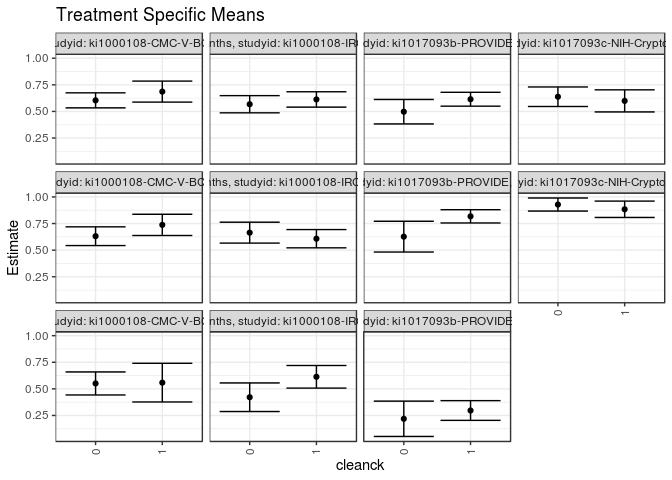

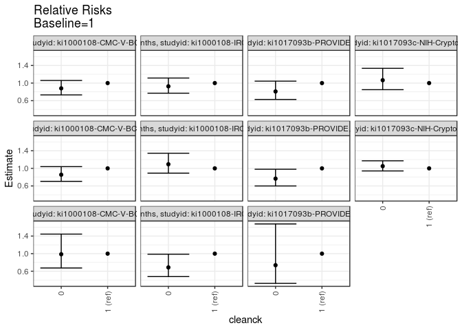

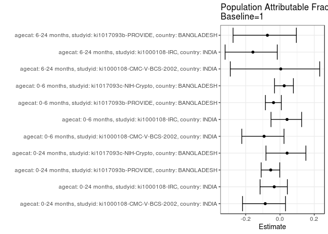

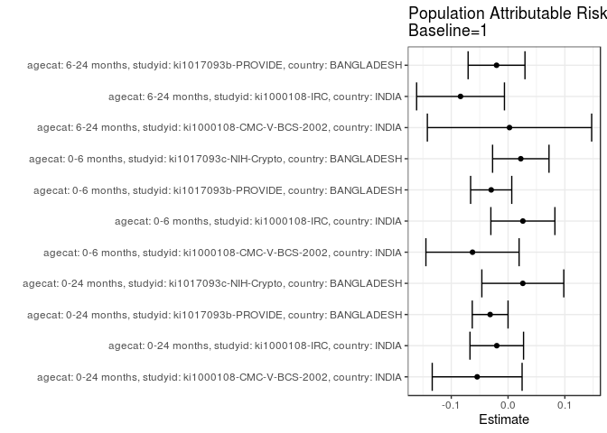

## Results Table

### Parameter: TSM

| agecat | studyid | country | intervention_level | baseline_level | estimate | ci_lower | ci_upper |
| --- | --- | --- | --- | --- | --- | --- | --- |
| 0-24 months | ki1000108-CMC-V-BCS-2002 | INDIA | 1 | NA | 0.6863160 | 0.5875490 | 0.7850829 |
| 0-24 months | ki1000108-CMC-V-BCS-2002 | INDIA | 0 | NA | 0.6040178 | 0.5334165 | 0.6746192 |
| 0-24 months | ki1000108-IRC | INDIA | 1 | NA | 0.6125833 | 0.5403859 | 0.6847806 |
| 0-24 months | ki1000108-IRC | INDIA | 0 | NA | 0.5675808 | 0.4868079 | 0.6483536 |
| 0-24 months | ki1017093b-PROVIDE | BANGLADESH | 1 | NA | 0.6146032 | 0.5495291 | 0.6796774 |
| 0-24 months | ki1017093b-PROVIDE | BANGLADESH | 0 | NA | 0.4974656 | 0.3825652 | 0.6123660 |
| 0-24 months | ki1017093c-NIH-Crypto | BANGLADESH | 1 | NA | 0.5990264 | 0.4953370 | 0.7027158 |
| 0-24 months | ki1017093c-NIH-Crypto | BANGLADESH | 0 | NA | 0.6382404 | 0.5465116 | 0.7299692 |
| 0-6 months | ki1000108-CMC-V-BCS-2002 | INDIA | 1 | NA | 0.7374930 | 0.6378471 | 0.8371389 |
| 0-6 months | ki1000108-CMC-V-BCS-2002 | INDIA | 0 | NA | 0.6311036 | 0.5432451 | 0.7189620 |
| 0-6 months | ki1000108-IRC | INDIA | 1 | NA | 0.6075255 | 0.5217585 | 0.6932925 |
| 0-6 months | ki1000108-IRC | INDIA | 0 | NA | 0.6644509 | 0.5662166 | 0.7626851 |
| 0-6 months | ki1017093b-PROVIDE | BANGLADESH | 1 | NA | 0.8177605 | 0.7553709 | 0.8801501 |
| 0-6 months | ki1017093b-PROVIDE | BANGLADESH | 0 | NA | 0.6267461 | 0.4821329 | 0.7713593 |
| 0-6 months | ki1017093c-NIH-Crypto | BANGLADESH | 1 | NA | 0.8840580 | 0.8071326 | 0.9609833 |
| 0-6 months | ki1017093c-NIH-Crypto | BANGLADESH | 0 | NA | 0.9285714 | 0.8672033 | 0.9899396 |
| 6-24 months | ki1000108-CMC-V-BCS-2002 | INDIA | 1 | NA | 0.5584401 | 0.3768040 | 0.7400763 |
| 6-24 months | ki1000108-CMC-V-BCS-2002 | INDIA | 0 | NA | 0.5508944 | 0.4427215 | 0.6590673 |
| 6-24 months | ki1000108-IRC | INDIA | 1 | NA | 0.6135065 | 0.5074671 | 0.7195460 |
| 6-24 months | ki1000108-IRC | INDIA | 0 | NA | 0.4214845 | 0.2871502 | 0.5558189 |
| 6-24 months | ki1017093b-PROVIDE | BANGLADESH | 1 | NA | 0.2967033 | 0.2039707 | 0.3894359 |
| 6-24 months | ki1017093b-PROVIDE | BANGLADESH | 0 | NA | 0.2187500 | 0.0526770 | 0.3848230 |

### Parameter: E(Y)

| agecat | studyid | country | intervention_level | baseline_level | estimate | ci_lower | ci_upper |
| --- | --- | --- | --- | --- | --- | --- | --- |
| 0-24 months | ki1000108-CMC-V-BCS-2002 | INDIA | NA | NA | 0.6319018 | 0.5759256 | 0.6878781 |
| 0-24 months | ki1000108-IRC | INDIA | NA | NA | 0.5926893 | 0.5398764 | 0.6455022 |
| 0-24 months | ki1017093b-PROVIDE | BANGLADESH | NA | NA | 0.5830619 | 0.5262762 | 0.6398476 |
| 0-24 months | ki1017093c-NIH-Crypto | BANGLADESH | NA | NA | 0.6250000 | 0.5603522 | 0.6896478 |
| 0-6 months | ki1000108-CMC-V-BCS-2002 | INDIA | NA | NA | 0.6748768 | 0.6092233 | 0.7405304 |
| 0-6 months | ki1000108-IRC | INDIA | NA | NA | 0.6336207 | 0.5704020 | 0.6968394 |
| 0-6 months | ki1017093b-PROVIDE | BANGLADESH | NA | NA | 0.7880435 | 0.7295878 | 0.8464992 |
| 0-6 months | ki1017093c-NIH-Crypto | BANGLADESH | NA | NA | 0.9064748 | 0.8572209 | 0.9557287 |
| 6-24 months | ki1000108-CMC-V-BCS-2002 | INDIA | NA | NA | 0.5609756 | 0.4682842 | 0.6536670 |
| 6-24 months | ki1000108-IRC | INDIA | NA | NA | 0.5298013 | 0.4450066 | 0.6145960 |
| 6-24 months | ki1017093b-PROVIDE | BANGLADESH | NA | NA | 0.2764228 | 0.1950773 | 0.3577682 |

### Parameter: RR

| agecat | studyid | country | intervention_level | baseline_level | estimate | ci_lower | ci_upper |
| --- | --- | --- | --- | --- | --- | --- | --- |
| 0-24 months | ki1000108-CMC-V-BCS-2002 | INDIA | 1 | 1 | 1.0000000 | 1.0000000 | 1.0000000 |
| 0-24 months | ki1000108-CMC-V-BCS-2002 | INDIA | 0 | 1 | 0.8800871 | 0.7309967 | 1.0595853 |
| 0-24 months | ki1000108-IRC | INDIA | 1 | 1 | 1.0000000 | 1.0000000 | 1.0000000 |
| 0-24 months | ki1000108-IRC | INDIA | 0 | 1 | 0.9265365 | 0.7699881 | 1.1149133 |
| 0-24 months | ki1017093b-PROVIDE | BANGLADESH | 1 | 1 | 1.0000000 | 1.0000000 | 1.0000000 |
| 0-24 months | ki1017093b-PROVIDE | BANGLADESH | 0 | 1 | 0.8094094 | 0.6275780 | 1.0439236 |
| 0-24 months | ki1017093c-NIH-Crypto | BANGLADESH | 1 | 1 | 1.0000000 | 1.0000000 | 1.0000000 |
| 0-24 months | ki1017093c-NIH-Crypto | BANGLADESH | 0 | 1 | 1.0654628 | 0.8497540 | 1.3359291 |
| 0-6 months | ki1000108-CMC-V-BCS-2002 | INDIA | 1 | 1 | 1.0000000 | 1.0000000 | 1.0000000 |
| 0-6 months | ki1000108-CMC-V-BCS-2002 | INDIA | 0 | 1 | 0.8557418 | 0.7044927 | 1.0394628 |
| 0-6 months | ki1000108-IRC | INDIA | 1 | 1 | 1.0000000 | 1.0000000 | 1.0000000 |
| 0-6 months | ki1000108-IRC | INDIA | 0 | 1 | 1.0937004 | 0.8909422 | 1.3426017 |
| 0-6 months | ki1017093b-PROVIDE | BANGLADESH | 1 | 1 | 1.0000000 | 1.0000000 | 1.0000000 |
| 0-6 months | ki1017093b-PROVIDE | BANGLADESH | 0 | 1 | 0.7664177 | 0.5994963 | 0.9798160 |
| 0-6 months | ki1017093c-NIH-Crypto | BANGLADESH | 1 | 1 | 1.0000000 | 1.0000000 | 1.0000000 |
| 0-6 months | ki1017093c-NIH-Crypto | BANGLADESH | 0 | 1 | 1.0503513 | 0.9416311 | 1.1716243 |
| 6-24 months | ki1000108-CMC-V-BCS-2002 | INDIA | 1 | 1 | 1.0000000 | 1.0000000 | 1.0000000 |
| 6-24 months | ki1000108-CMC-V-BCS-2002 | INDIA | 0 | 1 | 0.9864878 | 0.6736453 | 1.4446150 |
| 6-24 months | ki1000108-IRC | INDIA | 1 | 1 | 1.0000000 | 1.0000000 | 1.0000000 |
| 6-24 months | ki1000108-IRC | INDIA | 0 | 1 | 0.6870091 | 0.4781247 | 0.9871514 |
| 6-24 months | ki1017093b-PROVIDE | BANGLADESH | 1 | 1 | 1.0000000 | 1.0000000 | 1.0000000 |
| 6-24 months | ki1017093b-PROVIDE | BANGLADESH | 0 | 1 | 0.7372685 | 0.3243804 | 1.6757021 |

### Parameter: PAR

| agecat | studyid | country | intervention_level | baseline_level | estimate | ci_lower | ci_upper |
| --- | --- | --- | --- | --- | --- | --- | --- |
| 0-24 months | ki1000108-CMC-V-BCS-2002 | INDIA | 1 | NA | -0.0544141 | -0.1335473 | 0.0247190 |
| 0-24 months | ki1000108-IRC | INDIA | 1 | NA | -0.0198940 | -0.0670601 | 0.0272721 |
| 0-24 months | ki1017093b-PROVIDE | BANGLADESH | 1 | NA | -0.0315413 | -0.0630596 | -0.0000231 |
| 0-24 months | ki1017093c-NIH-Crypto | BANGLADESH | 1 | NA | 0.0259736 | -0.0461657 | 0.0981128 |
| 0-6 months | ki1000108-CMC-V-BCS-2002 | INDIA | 1 | NA | -0.0626162 | -0.1446638 | 0.0194315 |
| 0-6 months | ki1000108-IRC | INDIA | 1 | NA | 0.0260952 | -0.0303003 | 0.0824907 |
| 0-6 months | ki1017093b-PROVIDE | BANGLADESH | 1 | NA | -0.0297170 | -0.0659369 | 0.0065029 |
| 0-6 months | ki1017093c-NIH-Crypto | BANGLADESH | 1 | NA | 0.0224168 | -0.0272673 | 0.0721010 |
| 6-24 months | ki1000108-CMC-V-BCS-2002 | INDIA | 1 | NA | 0.0025355 | -0.1421176 | 0.1471885 |
| 6-24 months | ki1000108-IRC | INDIA | 1 | NA | -0.0837052 | -0.1610435 | -0.0063669 |
| 6-24 months | ki1017093b-PROVIDE | BANGLADESH | 1 | NA | -0.0202805 | -0.0703437 | 0.0297826 |

### Parameter: PAF

| agecat | studyid | country | intervention_level | baseline_level | estimate | ci_lower | ci_upper |
| --- | --- | --- | --- | --- | --- | --- | --- |
| 0-24 months | ki1000108-CMC-V-BCS-2002 | INDIA | 1 | NA | -0.0861117 | -0.2187604 | 0.0320997 |
| 0-24 months | ki1000108-IRC | INDIA | 1 | NA | -0.0335656 | -0.1162211 | 0.0429693 |
| 0-24 months | ki1017093b-PROVIDE | BANGLADESH | 1 | NA | -0.0540960 | -0.1098066 | -0.0011821 |
| 0-24 months | ki1017093c-NIH-Crypto | BANGLADESH | 1 | NA | 0.0415577 | -0.0819021 | 0.1509291 |
| 0-6 months | ki1000108-CMC-V-BCS-2002 | INDIA | 1 | NA | -0.0927816 | -0.2227866 | 0.0234014 |
| 0-6 months | ki1000108-IRC | INDIA | 1 | NA | 0.0411843 | -0.0522998 | 0.1263634 |
| 0-6 months | ki1017093b-PROVIDE | BANGLADESH | 1 | NA | -0.0377098 | -0.0853669 | 0.0078547 |
| 0-6 months | ki1017093c-NIH-Crypto | BANGLADESH | 1 | NA | 0.0247297 | -0.0319638 | 0.0783086 |
| 6-24 months | ki1000108-CMC-V-BCS-2002 | INDIA | 1 | NA | 0.0045197 | -0.2899441 | 0.2317644 |
| 6-24 months | ki1000108-IRC | INDIA | 1 | NA | -0.1579936 | -0.3201545 | -0.0157516 |
| 6-24 months | ki1017093b-PROVIDE | BANGLADESH | 1 | NA | -0.0733678 | -0.2738040 | 0.0955293 |